# Coding Challenge 5

DJT

2026-03-05

# Question 1

## Download two .csv files from Canvas called DiversityData.csv and Metadata.csv, and read them into R using relative file paths.

```r
setwd("~/PLPA_assignments")
data.meta<-read.csv("PLPA_assignments/Data/Metadata.csv", na.strings = "na")
data.div<-read.csv("PLPA_assignments/Data/Diversitydata.csv", na.strings = "na")
```

# Question 2

## Join the two dataframes together by the common column ‘Code’. Name the resulting dataframe alpha.

```r
alpha<-left_join(data.div, data.meta, by = "Code") #joining the dataframes
head(alpha)
```

```
##     Code  shannon invsimpson   simpson richness Crop Time_Point Replicate
## 1 S01_13 6.624921   210.7279 0.9952545     3319 Soil          0         1
## 2 S02_16 6.612413   206.8666 0.9951660     3079 Soil          0         2
## 3 S03_19 6.660853   213.0184 0.9953056     3935 Soil          0         3
## 4 S04_22 6.660671   204.6908 0.9951146     3922 Soil          0         4
## 5 S05_25 6.610965   200.2552 0.9950064     3196 Soil          0         5
## 6 S06_28 6.650812   199.3211 0.9949830     3481 Soil          0         6
##   Water_Imbibed
## 1            NA
## 2            NA
## 3            NA
## 4            NA
## 5            NA
## 6            NA
```

# Question 3

## Calculate Pielou’s evenness index: Pielou’s evenness is an ecological parameter calculated by the Shannon diversity index (column Shannon) divided by the log of the richness column

### a. Using mutate, create a new column to calculate Pielou’s evenness index.

### b. Name the resulting dataframe alpha_even.

```r
alpha_even <- alpha %>%
  mutate(alpha, pielou = shannon/log(richness)) #new dataframe called alpha_even with a new column calculating Pielou's evenness
head(alpha_even)
```

```
##     Code  shannon invsimpson   simpson richness Crop Time_Point Replicate
## 1 S01_13 6.624921   210.7279 0.9952545     3319 Soil          0         1
## 2 S02_16 6.612413   206.8666 0.9951660     3079 Soil          0         2
## 3 S03_19 6.660853   213.0184 0.9953056     3935 Soil          0         3
## 4 S04_22 6.660671   204.6908 0.9951146     3922 Soil          0         4
## 5 S05_25 6.610965   200.2552 0.9950064     3196 Soil          0         5
## 6 S06_28 6.650812   199.3211 0.9949830     3481 Soil          0         6
##   Water_Imbibed    pielou
## 1            NA 0.8171431
## 2            NA 0.8232216
## 3            NA 0.8046776
## 4            NA 0.8049774
## 5            NA 0.8192376
## 6            NA 0.8155427
```

# Question 4

## Using tidyverse language of functions and the pipe, use the summarise function and tell me the mean and standard error evenness grouped by crop over time.

### a. Start with the alpha_even dataframe

### b. Group the data: group the data by Crop and Time_Point.

### c. Summarize the data: Calculate the mean, count, standard deviation, and standard error for the even variable within each group.

### d. Name the resulting dataframe alpha_average

```r
alpha_average<-alpha_even %>%
  group_by(Crop, Time_Point)%>% # grouped by Crop and Time Pint
  summarise(Mean.pielou = mean(pielou), #stats via summarize
            n = n(),
            sd.dev = sd(pielou)) %>%
  mutate(std.err = sd.dev/sqrt(n)) #adding a column for standard dev.
head(alpha_average)
```

```
## # A tibble: 6 × 6
## # Groups:   Crop [2]
##   Crop   Time_Point Mean.pielou     n  sd.dev std.err
##   <chr>       <int>       <dbl> <int>   <dbl>   <dbl>
## 1 Cotton          0       0.820     6 0.00556 0.00227
## 2 Cotton          6       0.805     6 0.00920 0.00376
## 3 Cotton         12       0.767     6 0.0157  0.00640
## 4 Cotton         18       0.755     5 0.0169  0.00755
## 5 Soil            0       0.814     6 0.00765 0.00312
## 6 Soil            6       0.810     6 0.00587 0.00240
```

```r
alpha_average
```

```
## # A tibble: 12 × 6
## # Groups:   Crop [3]
##    Crop    Time_Point Mean.pielou     n  sd.dev std.err
##    <chr>        <int>       <dbl> <int>   <dbl>   <dbl>
##  1 Cotton           0       0.820     6 0.00556 0.00227
##  2 Cotton           6       0.805     6 0.00920 0.00376
##  3 Cotton          12       0.767     6 0.0157  0.00640
##  4 Cotton          18       0.755     5 0.0169  0.00755
##  5 Soil             0       0.814     6 0.00765 0.00312
##  6 Soil             6       0.810     6 0.00587 0.00240
##  7 Soil            12       0.798     6 0.00782 0.00319
##  8 Soil            18       0.800     5 0.0104  0.00465
##  9 Soybean          0       0.822     6 0.00270 0.00110
## 10 Soybean          6       0.764     6 0.0400  0.0163
## 11 Soybean         12       0.687     6 0.0643  0.0263
## 12 Soybean         18       0.716     6 0.0153  0.00626
```

# Question 5

## Calculate the difference between the soybean column, the soil column, and the difference between the cotton column and the soil column

### a. Start with the alpha_average dataframe

### b. Select relevant columns: select the columns Time_Point, Crop, and mean.even.

### c. Reshape the data: Use the pivot_wider function to transform the data from long to wide format, creating new columns for each Crop with values from mean.even.

### d. Calculate differences: Create new columns named diff.cotton.even and diff.soybean.even by calculating the difference between Soil and Cotton, and Soil and Soybean, respectively.

### e. Name the resulting dataframe alpha_average2

```r
alpha_average2 <- alpha_average %>%
  select(Time_Point, Crop, Mean.pielou)%>% # Select relevant columns
  pivot_wider(names_from = Crop, values_from = Mean.pielou)%>% # Reshape the data creating new columns for each Crop with values from mean.even
  mutate(diff.cotton.even = Soil - Cotton, diff.soybean.even = Soil - Soybean) #Calculated difference between two new columns named diff.cotton.even and diff.soybean.even
head(alpha_average2)
```

```
## # A tibble: 4 × 6
##   Time_Point Cotton  Soil Soybean diff.cotton.even diff.soybean.even
##        <int>  <dbl> <dbl>   <dbl>            <dbl>             <dbl>
## 1          0  0.820 0.814   0.822         -0.00602          -0.00740
## 2          6  0.805 0.810   0.764          0.00507           0.0459
## 3         12  0.767 0.798   0.687          0.0313            0.112
## 4         18  0.755 0.800   0.716          0.0449            0.0833
```

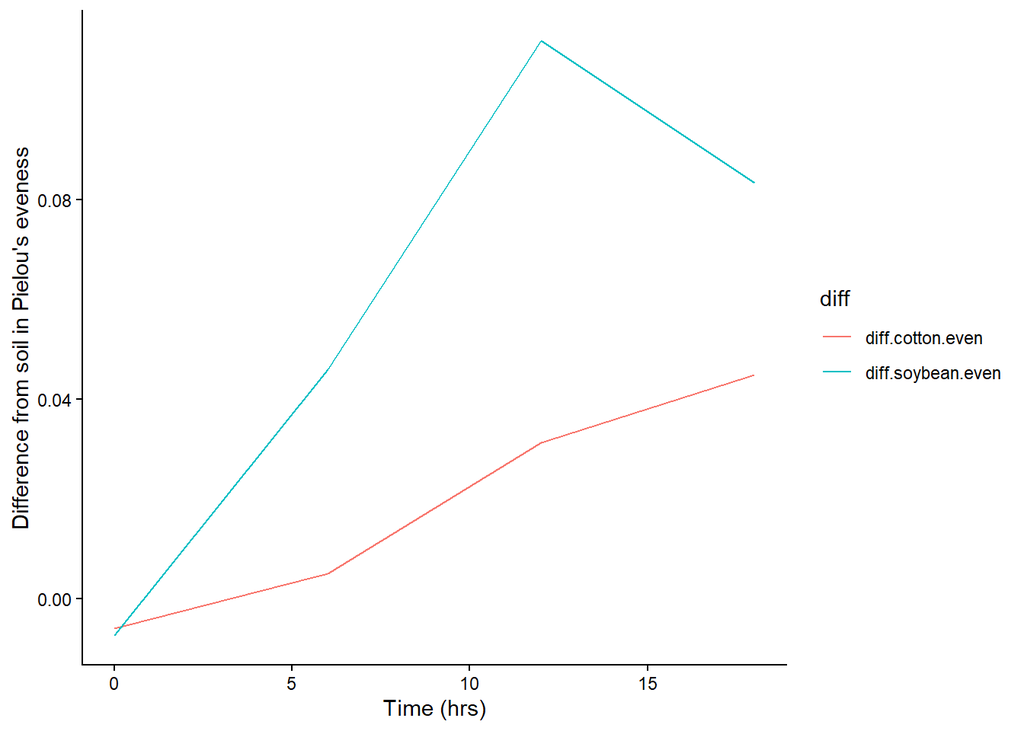

```r
alpha_average2 %>%
  select(Time_Point, diff.cotton.even, diff.soybean.even)%>% #Select relevant columns
   pivot_longer(c(diff.cotton.even, diff.soybean.even), names_to = "diff", values_to = "values")%>% # Reshape the data to long form with new column named diff that contains the values from diff.cotton.even and diff.soybean.even.
    ggplot(aes(x = Time_Point, y = values, color = diff, group = diff))+ #ggplot with aes layering and classic theme
    geom_line()+
    theme_classic()+
    xlab("Time (hrs)") +
    ylab("Difference from soil in Pielou's eveness")
```

# Question 7

## Commit and push a gfm .md file to GitHub inside a directory called Coding Challenge 5. Provide me a link to your github written as a clickable link in your .pdf or .docx